# Conjoint Survey Analysis

Author

Mehul, Nisha, Aman

Published

December 10, 2024

```r
library(surveydown)
library(dplyr)
library(glue)
library(tidyverse)
library(fastDummies)
library(here)
library(lubridate)
library(logitr)
library(janitor)
library(cbcTools)
library(MASS)
```

### Introduction

Genetic sequencing services offer consumers insights into ancestry, health, and wellness, fueling a growing demand for personalized genetic data. This study evaluates consumer preferences for various service attributes to optimize product offerings and pricing strategies. The attributes studied include price, delivery time, report type, and support services. These attributes are essential for understanding the factors influencing consumer decision-making.

### Survey Design

#### Eligibility Requirements

- **Age**: Respondents aged 18 or older were eligible.
- **Consent**: Informed consent was obtained to ensure ethical participation.

#### Changes Between Pilot and Final Survey

- Revised attribute descriptions for clarity.
- Expanded respondent demographics by altering distribution methods.

#### Example Conjoint Question

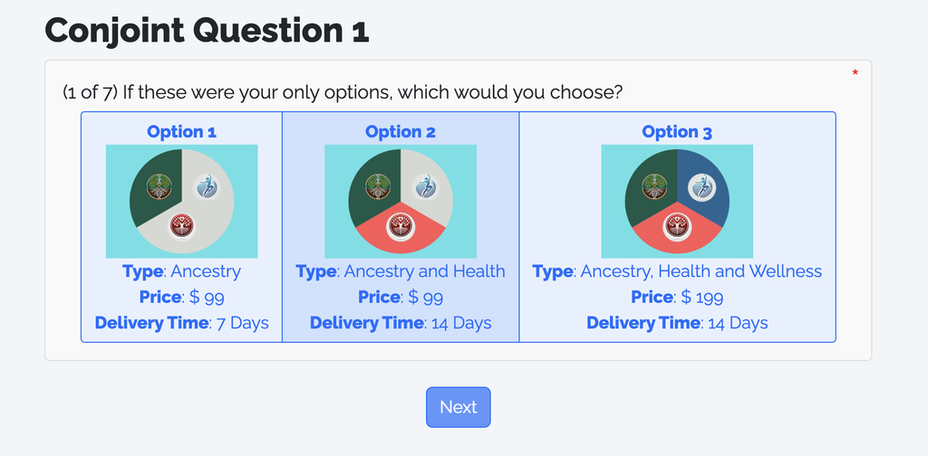

Choice-based Conjoint Practice Example

### Data Analysis

#### Sample Description

The survey initially gathered responses from a total of **248 respondents**. After applying eligibility criteria and screening out individuals based on consistency and response time, the final valid sample size was **162 respondents**. The following process outlines how the final sample was obtained:

1. **Initial Responses**: 248 respondents completed the survey.
2. **Screening Out Ineligible Respondents**:
   - **35 respondents** were removed for not meeting basic eligibility criteria or providing incomplete responses, leaving **213 respondents**.
3. **Removing Patterned Responses**:
   - Respondents who selected the same option for every question were flagged as inattentive, further reducing the sample size to **173 respondents**.
4. **Response Time Validation**:
   - A threshold of **1 minute or more** was set as the minimum time required to complete the survey to ensure thoughtful responses. This criterion excluded **11 additional respondents**, resulting in **162 valid responses**.

##### Gender Distribution

| Gender | Count | Percentage |
| --- | --- | --- |
| Male | 107 | 37.68% |
| Female | 84 | 29.58% |
| Non-binary | 2 | 0.70% |
| Trans Female | 2 | 0.70% |
| Trans Male | 1 | 0.35% |
| Prefer Not to Say | 2 | 0.70% |
| Other | 86 | 30.28% |

##### Previous Service Usage

The majority of respondents (**80.28%**) had not used direct-to-consumer genetic sequencing services before. Among those who had, the most frequently mentioned services included:

- **23andMe** (various spellings): 18 respondents.
- **Ancestry DNA**: 10 respondents.
- Other services: Helix, Illumina, MyHeritage, and smaller providers.

##### Education Levels

| Education Level | Count | Percentage |
| --- | --- | --- |
| High School or Less | 25 | 8.80% |
| Some College | 37 | 13.03% |
| Associate Degree | 26 | 9.15% |
| Bachelor’s Degree | 73 | 25.70% |
| Master’s Degree | 32 | 11.27% |
| Doctoral Degree | 7 | 2.46% |

### Data Cleaning

#### Filtering Criteria

1. **Incomplete or Invalid Responses**:
   - Respondents with incomplete demographic or conjoint question answers were excluded.
2. **Patterned Responses**:
   - Responses exhibiting repetitive patterns (e.g., selecting the same option across all questions) were flagged and removed.
3. **Inadequate Response Time**:
   - A threshold of at least **1 minute** was set for survey completion time. Respondents below this threshold were excluded to eliminate rushed and potentially inaccurate responses.

#### Summary of Data Cleaning

- **Total Respondents Initially**: 248
- **Removed Due to Ineligibility or Incomplete Responses**: 35
- **Excluded for Patterned Responses**: 40
- **Excluded for Insufficient Response Time**: 11
- **Final Valid Responses**: 162

### Results Visualization

**Gender Distribution Plot**

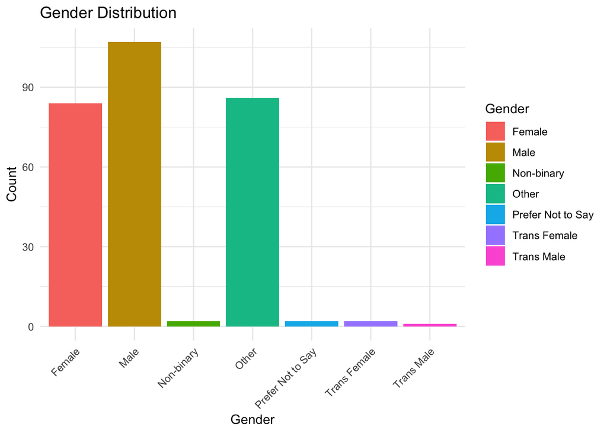

```r
library(ggplot2)
gender_data <- data.frame(
  Gender = c("Male", "Female", "Non-binary", "Trans Female", "Trans Male", "Prefer Not to Say", "Other"),
  Count = c(107, 84, 2, 2, 1, 2, 86)
)
ggplot(gender_data, aes(x = Gender, y = Count, fill = Gender)) +
  geom_bar(stat = "identity") +
  theme_minimal() +
  labs(title = "Gender Distribution", x = "Gender", y = "Count") +
  theme(axis.text.x = element_text(angle = 45, hjust = 1))
```

Education Level Plot

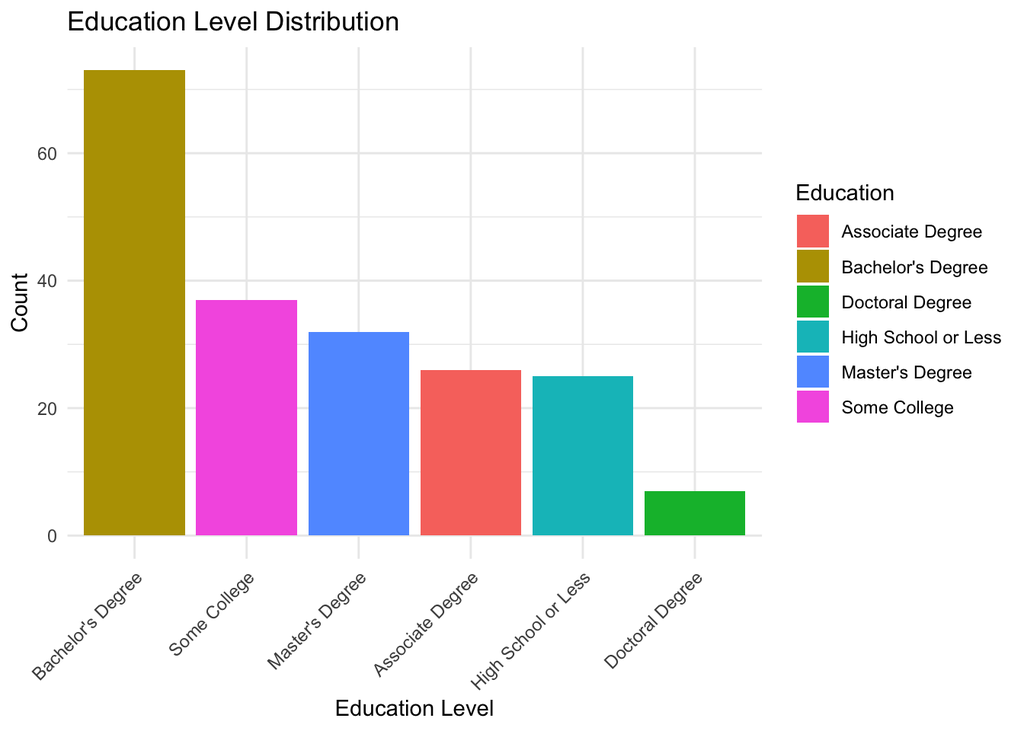

```r
education_data <- data.frame(
  Education = c("High School or Less", "Some College", "Associate Degree", "Bachelor's Degree", "Master's Degree", "Doctoral Degree"),
  Count = c(25, 37, 26, 73, 32, 7)
)
ggplot(education_data, aes(x = reorder(Education, -Count), y = Count, fill = Education)) +
  geom_bar(stat = "identity") +
  theme_minimal() +
  labs(title = "Education Level Distribution", x = "Education Level", y = "Count") +
  theme(axis.text.x = element_text(angle = 45, hjust = 1))
```

Previous Service Usage Plot

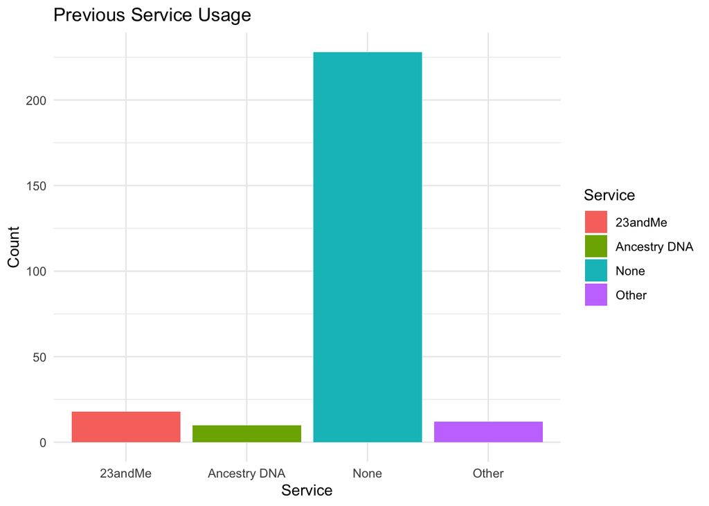

```r
service_data <- data.frame(
  Service = c("None", "23andMe", "Ancestry DNA", "Other"),
  Count = c(228, 18, 10, 12)
)
ggplot(service_data, aes(x = Service, y = Count, fill = Service)) +
  geom_bar(stat = "identity") +
  theme_minimal() +
  labs(title = "Previous Service Usage", x = "Service", y = "Count")
```

#### Modeling

Baseline utility model (Logit):

The utility $U_{ij}$ that respondent $i$ derives from choosing option $j$ is modeled as:

$$U_{ij} = \beta_1 \cdot x_j^{(\text{price})} + \beta_2 \cdot x_j^{(\text{delivery\_time})} + \beta_3 \cdot \delta_j^{(\text{Ancestry\_and\_Health})} + \beta_4 \cdot \delta_j^{(\text{Ancestry\_Health\_and\_Wellness})} + \epsilon_{ij}$$

### Where:

- $x_j^{(\text{price})}$: Continuous variable for the price of the option.
- $x_j^{(\text{delivery\_time})}$: Continuous variable for the delivery time of the option.
- $\delta_j^{(\text{Ancestry\_and\_Health})}$: Dummy variable indicating if the option includes ancestry and health reports.
- $\delta_j^{(\text{Ancestry\_Health\_and\_Wellness})}$: Dummy variable indicating if the option includes ancestry, health, and wellness reports.
- $\beta_1, \beta_2, \beta_3, \beta_4$: Coefficients representing the impact of each attribute on utility.
- $\epsilon_{ij}$: Random error term accounting for unobserved factors.

### Coefficients:

| Attribute | Coefficient ($\beta$) | Value |
| --- | --- | --- |
| $x_j^{(\text{price})}$ | $\beta_1$ | -0.01677 |
| $x_j^{(\text{delivery\_time})}$ | $\beta_2$ | -0.02201 |
| $\delta_j^{(\text{Ancestry\_and\_Health})}$ | $\beta_3$ | 1.44516 |
| $\delta_j^{(\text{Ancestry\_Health\_and\_Wellness})}$ | $\beta_4$ | 2.15981 |

### Results

#### Willingness-to-Pay (WTP)

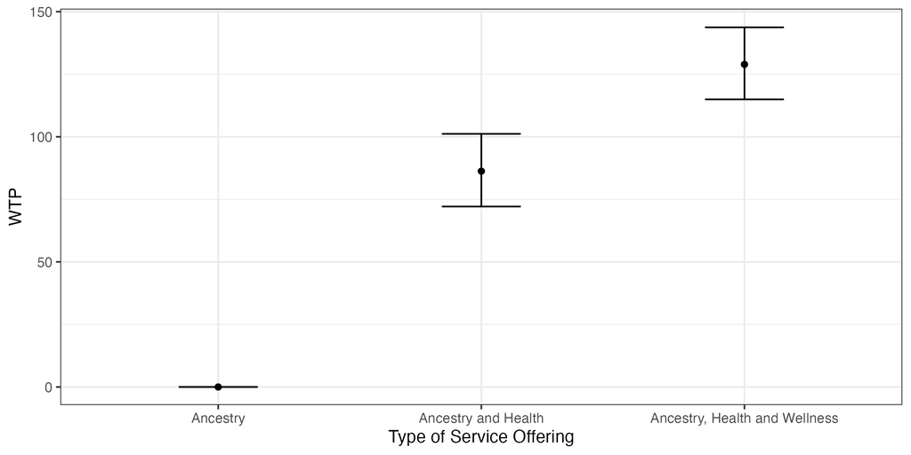

WTP at mean and 95% confidence intervals

## Simulated Market Scenarios

#### **Market Attributes**

The following table summarizes the attributes of the simulated products in a competitive scenario from one of the competitors:

| **Price ($)** | **Delivery Time (Days)** | **Report Type** |  |
| --- | --- | --- | --- |
| 149 | 14 | Basic Ancestry |  |
| 249 | 14 | Ancestry and Health |  |
| 399 | 20 | Ancestry, Health, and Wellness |  |

#### **Simulated Market Shares**

The multinomial logit model was used to simulate market shares for the above scenario. The results are as follows:

```r
competitor1 <- matrix(c(
  149, 0, 0, 14,
  249, 1, 0, 14,
  399, 0, 1, 20),
  ncol = 4, byrow = TRUE)

load(here("models", "model.RData"))

beta <- coef(model_dummy)

v_j <- competitor1 %*% beta
exp_v_j <- exp(v_j)

P_j <- exp_v_j / sum(exp_v_j)

#we get market shares of alternative offered by competitor 1
P_j
```

```
           [,1]
[1,] 0.52413635
[2,] 0.41569852
[3,] 0.06016513
```

### **Sensitivity of Market Demand Predictions to Product Attributes**

#### **Impact of Product Attributes**

The sensitivity analysis highlights how changes in key product attributes—price, report type, and delivery time—affect market demand predictions. Among these, report type (specifically options including ancestry, health, and wellness) has the most significant impact on consumer preferences. Price and delivery time also play an important role, but their effects are relatively smaller compared to report type.

### **Sensitivity Analysis Plot**

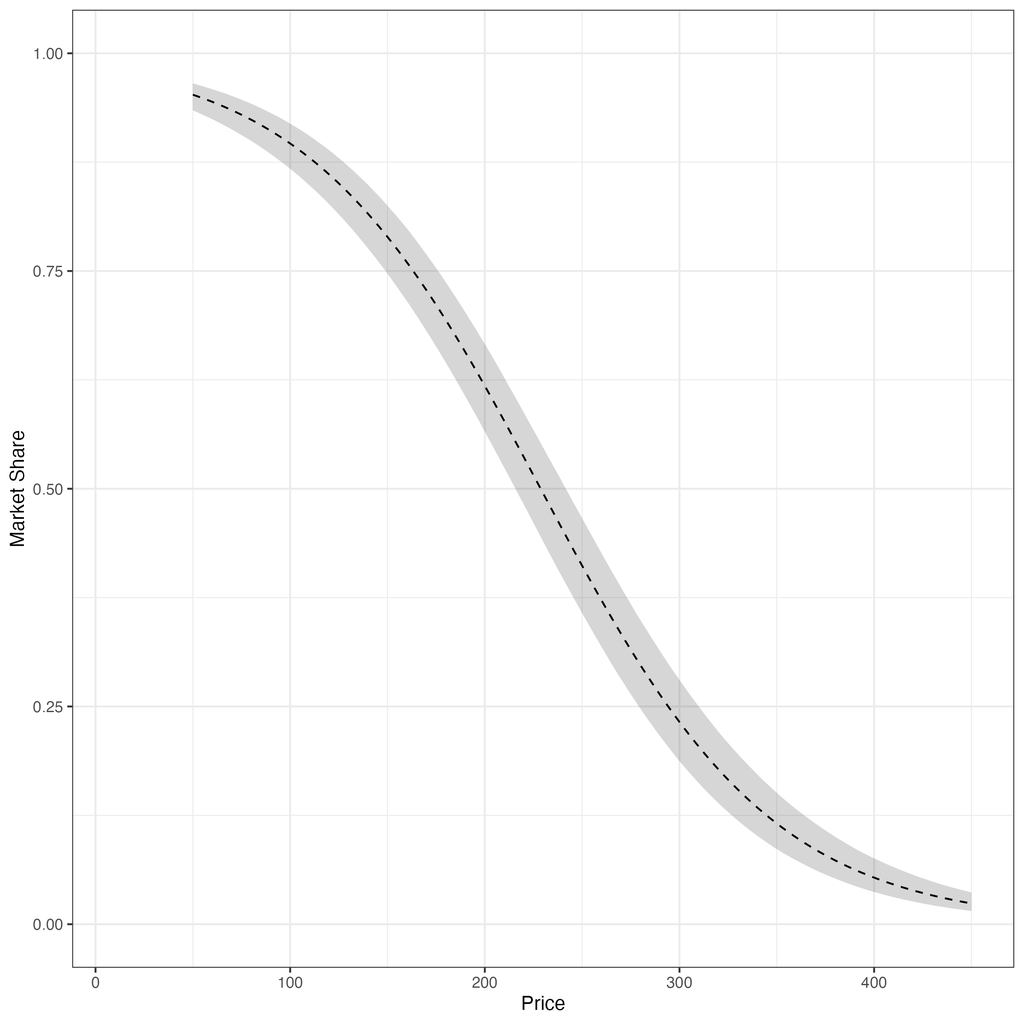

Sensitivity Analysis

#### **Tornado Plot**

[figure not shown]

```r
# Load necessary library
library(ggplot2)

# Create example data
sensitivity_data <- data.frame(
  Price = c(99, 199, 299),
  `Health and Wellness` = c(60, 45, 25),
  `Ancestry and Health` = c(50, 40, 20),
  `Basic Ancestry` = c(40, 30, 15)
)

# Set 199 as the baseline
baseline <- sensitivity_data[sensitivity_data$Price == 199, -1]

# Calculate changes relative to the baseline
sensitivity <- sensitivity_data
sensitivity[,-1] <- sensitivity[,-1] - as.numeric(baseline)

# Reshape data for plotting
library(reshape2)
sensitivity_melted <- melt(sensitivity, id.vars = "Price", variable.name = "Attribute", value.name = "Change")

# Plot tornado chart
ggplot(sensitivity_melted, aes(x = Change, y = factor(Price, levels = rev(unique(Price))), fill = Attribute)) +
  geom_bar(stat = "identity", position = "dodge") +
  labs(
    title = "Tornado Plot: Sensitivity of Market Shares to Price Changes",
    x = "Change in Market Share (%)",
    y = "Price ($)"
  ) +
  theme_minimal() +
  theme(legend.position = "bottom")
```

### **Potential Against Competitors**

Yes, the product has the potential to be highly competitive against current competitors in the direct-to-consumer genetic sequencing market. Key findings indicate that consumers strongly value comprehensive reports that include ancestry, health, and wellness features. These insights position the product favorably against alternatives that may not offer such detailed reporting or personalized support services.

#### **Optimal Price Range**

- The price sensitivity analysis indicates that the $99 and $199 price tiers are the most appealing to consumers.
- The $99 tier attracts the largest share of customers, but the $199 tier balances affordability with profitability by leveraging the strong appeal of enhanced features like wellness reporting.

#### **Confidence in Competitiveness**

- The model coefficients show significant preference for high-value attributes (e.g., ancestry, health, and wellness reports), with robust standard errors indicating reliability.
- Confidence in the recommendations is high due to consistent patterns in consumer preferences, but further validation with a broader sample may increase certainty.

#### **Key Unknowns or Uncertainties**

- **Market Dynamics**: How competitors may adjust their offerings or prices in response to this product’s features.
- **Consumer Behavior**: Variations in preferences across geographic regions or demographic groups that were not fully captured in the current analysis.
- **Operational Challenges**: Costs or delays associated with offering faster delivery or more comprehensive reports.

### **Recommendations**

#### **Key Decisions on Price**

1. **Primary Pricing Strategy**:
   - Launch the product at the $199 price point to maximize revenue while maintaining consumer appeal.
   - Offer a basic version at $99 to attract price-sensitive customers, ensuring broad market coverage.
2. **Tiered Options**:
   - Introduce premium add-ons like personalized consultations or expedited delivery for an additional fee.

#### **Decisions on Delivery**

- Focus on reducing delivery times to less than 14 days to improve customer satisfaction without significantly increasing costs.

#### **Robustness of Recommendations**

- Recommendations are robust, as they align with consumer preferences revealed in the utility model.
- However, the inclusion of additional demographic or regional data could enhance precision.

### **Top Opportunities to Increase Demand**

1. **Feature Differentiation**:
   - Promote the inclusion of ancestry, health, and wellness reports as a unique selling point.
   - Highlight personalized consultation services to create added value.
2. **Flexible Pricing Models**:
   - Introduce subscription-based pricing for recurring updates or additional health insights.
3. **Marketing Strategy**:
   - Target health-conscious consumers and families who are likely to value comprehensive wellness reports.
   - Use testimonials and evidence-based results to build trust and credibility.

### **Limitations**

1. **Sample Representativeness**:
   - The survey sample may not fully represent all potential customer demographics or geographic regions, which could affect the generalizability of results.
2. **Attribute Assumptions**:
   - Some attributes (e.g., delivery time, report type) were predefined and may not capture all factors influencing consumer choice.
3. **Competitor Response**:
   - The analysis assumes static market conditions and does not account for potential reactions from competitors, such as price changes or feature upgrades.
4. **Operational Feasibility**:
   - The ability to deliver faster services or comprehensive reports depends on operational capabilities, which were not modeled in this analysis.